# Financial Big Data HW 2

108070014 陳品妤

### Question 1

```r
market <- read.csv("marketing_data.csv")
str(market)
```

```
## 'data.frame':    2240 obs. of  28 variables:
##  $ ID                 : int  1826 1 10476 1386 5371 7348 4073 1991 4047 9477 ...
##  $ Year_Birth         : int  1970 1961 1958 1967 1989 1958 1954 1967 1954 1954 ...
##  $ Education          : chr  "Graduation" "Graduation" "Graduation" "Graduation" ...
##  $ Marital_Status     : chr  "Divorced" "Single" "Married" "Together" ...
##  $ Income             : chr  "$84,835.00 " "$57,091.00 " "$67,267.00 " "$32,474.00 " ...
##  $ Kidhome            : int  0 0 0 1 1 0 0 0 0 0 ...
##  $ Teenhome           : int  0 0 1 1 0 0 0 1 1 1 ...
##  $ Dt_Customer        : chr  "6/16/14" "6/15/14" "5/13/14" "5/11/14" ...
##  $ Recency            : int  0 0 0 0 0 0 0 0 0 0 ...
##  $ MntWines           : int  189 464 134 10 6 336 769 78 384 384 ...
##  $ MntFruits          : int  104 5 11 0 16 130 80 0 0 0 ...
##  $ MntMeatProducts    : int  379 64 59 1 24 411 252 11 102 102 ...
##  $ MntFishProducts    : int  111 7 15 0 11 240 15 0 21 21 ...
##  $ MntSweetProducts   : int  189 0 2 0 0 32 34 0 32 32 ...
##  $ MntGoldProds       : int  218 37 30 0 34 43 65 7 5 5 ...
##  $ NumDealsPurchases  : int  1 1 1 1 2 1 1 1 3 3 ...
##  $ NumWebPurchases    : int  4 7 3 1 3 4 10 2 6 6 ...
##  $ NumCatalogPurchases: int  4 3 2 0 1 7 10 1 2 2 ...
##  $ NumStorePurchases  : int  6 7 5 2 2 5 7 3 9 9 ...
##  $ NumWebVisitsMonth  : int  1 5 2 7 7 2 6 5 4 4 ...
##  $ AcceptedCmp3       : int  0 0 0 0 1 0 1 0 0 0 ...
##  $ AcceptedCmp4       : int  0 0 0 0 0 0 0 0 0 0 ...
##  $ AcceptedCmp5       : int  0 0 0 0 0 0 0 0 0 0 ...
##  $ AcceptedCmp1       : int  0 0 0 0 0 0 0 0 0 0 ...
##  $ AcceptedCmp2       : int  0 1 0 0 0 0 0 0 0 0 ...
##  $ Response           : int  1 1 0 0 1 1 1 0 0 0 ...
##  $ Complain           : int  0 0 0 0 0 0 0 0 0 0 ...
##  $ Country            : chr  "SP" "CA" "US" "AUS" ...
```

```r
skim(market) %>%
  print(rule_width = 150)
```

```
## ── Data Summary ────────────────────────
##                            Values
## Name                       market
## Number of rows             2240
## Number of columns          28
## _______________________
## Column type frequency:
##   character                5
##   numeric                  23
## ________________________
## Group variables            None
##
## ── Variable type: character ────────────────────────────────────────────────────────────────────────
##   skim_variable  n_missing complete_rate min max empty n_unique whitespace
## 1 Education              0             1   3  10     0        5          0
```

[output cut: 54 more lines]

### Question 2

```r
ls(market)
```

```
##  [1] "AcceptedCmp1"        "AcceptedCmp2"        "AcceptedCmp3"        "AcceptedCmp4"
##  [5] "AcceptedCmp5"        "Complain"            "Country"             "Dt_Customer"
##  [9] "Education"           "ID"                  "Income"              "Kidhome"
## [13] "Marital_Status"      "MntFishProducts"     "MntFruits"           "MntGoldProds"
## [17] "MntMeatProducts"     "MntSweetProducts"    "MntWines"            "NumCatalogPurchases"
## [21] "NumDealsPurchases"   "NumStorePurchases"   "NumWebPurchases"     "NumWebVisitsMonth"
## [25] "Recency"             "Response"            "Teenhome"            "Year_Birth"
```

### Question 3

```r
sum(is.na(market))
```

```
## [1] 0
```

### Question 4

```r
colSums(is.na(market))
```

```
##                  ID          Year_Birth           Education      Marital_Status              Income
##                   0                   0                   0                   0                   0
##             Kidhome            Teenhome         Dt_Customer             Recency            MntWines
##                   0                   0                   0                   0                   0
##           MntFruits     MntMeatProducts     MntFishProducts    MntSweetProducts        MntGoldProds
##                   0                   0                   0                   0                   0
##   NumDealsPurchases     NumWebPurchases NumCatalogPurchases   NumStorePurchases   NumWebVisitsMonth
##                   0                   0                   0                   0                   0
##        AcceptedCmp3        AcceptedCmp4        AcceptedCmp5        AcceptedCmp1        AcceptedCmp2
##                   0                   0                   0                   0                   0
##            Response            Complain             Country
##                   0                   0                   0
```

### Question 5

```r
describe(market) %>% html()
```

market  
28 Variables 2240 Observations

ID

```
        n  missing distinct     Info     Mean      Gmd      .05      .10      .25
     2240        0     2240        1     5592     3749    576.9   1126.1   2828.2
      .50      .75      .90      .95
   5458.5   8427.8  10203.4  10675.0
```

lowest : 0 1 9 13 17 , highest: 11178 11181 11187 11188 11191

Year_Birth

| n | missing | distinct | Info | Mean | Gmd | .05 | .10 | .25 | .50 | .75 | .90 | .95 |
| --- | --- | --- | --- | --- | --- | --- | --- | --- | --- | --- | --- | --- |
| 2240 | 0 | 59 | 0.999 | 1969 | 13.57 | 1950 | 1952 | 1959 | 1970 | 1977 | 1984 | 1988 |

lowest : 1893 1899 1900 1940 1941 , highest: 1992 1993 1994 1995 1996

Education

| n | missing | distinct |
| --- | --- | --- |
| 2240 | 0 | 5 |

| lowest : | 2n Cycle | Basic | Graduation | Master | PhD |
| --- | --- | --- | --- | --- | --- |
| highest: | 2n Cycle | Basic | Graduation | Master | PhD |

```
 Value        2n Cycle      Basic Graduation     Master        PhD
 Frequency         203         54       1127        370        486
 Proportion      0.091      0.024      0.503      0.165      0.217
```

Marital_Status

| n | missing | distinct |
| --- | --- | --- |
| 2240 | 0 | 8 |

lowest : Absurd Alone Divorced Married Single , highest: Married Single Together Widow YOLO

```
 Value        Absurd    Alone Divorced  Married   Single Together    Widow     YOLO
 Frequency         2        3      232      864      480      580       77        2
 Proportion    0.001    0.001    0.104    0.386    0.214    0.259    0.034    0.001
```

Income

| n | missing | distinct |
| --- | --- | --- |
| 2216 | 24 | 1974 |

| lowest : | $1,730.00 | $10,245.00 | $10,404.00 | $10,979.00 | $101,970.00 |
| --- | --- | --- | --- | --- | --- |
| highest: | $95,529.00 | $96,547.00 | $96,843.00 | $96,876.00 | $98,777.00 |

Kidhome

| n | missing | distinct | Info | Mean | Gmd |
| --- | --- | --- | --- | --- | --- |
| 2240 | 0 | 3 | 0.743 | 0.4442 | 0.5302 |

```
 Value          0     1     2
 Frequency   1293   899    48
 Proportion 0.577 0.401 0.021
```

Teenhome

| n | missing | distinct | Info | Mean | Gmd |
| --- | --- | --- | --- | --- | --- |
| 2240 | 0 | 3 | 0.765 | 0.5062 | 0.545 |

```
 Value          0     1     2
 Frequency   1158  1030    52
 Proportion 0.517 0.460 0.023
```

Dt_Customer

| n | missing | distinct |
| --- | --- | --- |
| 2240 | 0 | 663 |

lowest : 1/1/13 1/1/14 1/10/13 1/10/14 1/11/13 , highest: 9/7/12 9/7/13 9/8/12 9/9/12 9/9/13

Recency

| n | missing | distinct | Info | Mean | Gmd | .05 | .10 | .25 | .50 | .75 | .90 | .95 |
| --- | --- | --- | --- | --- | --- | --- | --- | --- | --- | --- | --- | --- |
| 2240 | 0 | 100 | 1 | 49.11 | 33.45 | 4 | 9 | 24 | 49 | 74 | 89 | 94 |

lowest : 0 1 2 3 4 , highest: 95 96 97 98 99

MntWines

```
        n  missing distinct     Info     Mean      Gmd      .05      .10      .25
     2240        0      776        1    303.9    355.3     3.00     6.00    23.75
      .50      .75      .90      .95
   173.50   504.25   822.10  1000.00
```

lowest : 0 1 2 3 4 , highest: 1462 1478 1486 1492 1493

MntFruits

| n | missing | distinct | Info | Mean | Gmd | .05 | .10 | .25 | .50 | .75 | .90 | .95 |
| --- | --- | --- | --- | --- | --- | --- | --- | --- | --- | --- | --- | --- |
| 2240 | 0 | 158 | 0.993 | 26.3 | 36.3 | 0 | 0 | 1 | 8 | 33 | 83 | 123 |

lowest : 0 1 2 3 4 , highest: 190 193 194 197 199

MntMeatProducts

| n | missing | distinct | Info | Mean | Gmd | .05 | .10 | .25 | .50 | .75 | .90 | .95 |
| --- | --- | --- | --- | --- | --- | --- | --- | --- | --- | --- | --- | --- |
| 2240 | 0 | 558 | 1 | 166.9 | 213.8 | 4.0 | 7.0 | 16.0 | 67.0 | 232.0 | 499.0 | 687.1 |

lowest : 0 1 2 3 4 , highest: 984 1582 1607 1622 1725

MntFishProducts

| n | missing | distinct | Info | Mean | Gmd | .05 | .10 | .25 | .50 | .75 | .90 | .95 |
| --- | --- | --- | --- | --- | --- | --- | --- | --- | --- | --- | --- | --- |
| 2240 | 0 | 182 | 0.994 | 37.53 | 51.03 | 0 | 0 | 3 | 12 | 50 | 120 | 168 |

lowest : 0 1 2 3 4 , highest: 250 253 254 258 259

MntSweetProducts

| n | missing | distinct | Info | Mean | Gmd | .05 | .10 | .25 | .50 | .75 | .90 | .95 |
| --- | --- | --- | --- | --- | --- | --- | --- | --- | --- | --- | --- | --- |
| 2240 | 0 | 177 | 0.993 | 27.06 | 37.55 | 0 | 0 | 1 | 8 | 33 | 89 | 126 |

lowest : 0 1 2 3 4 , highest: 196 197 198 262 263

MntGoldProds

| n | missing | distinct | Info | Mean | Gmd | .05 | .10 | .25 | .50 | .75 | .90 | .95 |
| --- | --- | --- | --- | --- | --- | --- | --- | --- | --- | --- | --- | --- |
| 2240 | 0 | 213 | 1 | 44.02 | 50.7 | 1 | 3 | 9 | 24 | 56 | 122 | 165 |

lowest : 0 1 2 3 4 , highest: 249 262 291 321 362

NumDealsPurchases

| n | missing | distinct | Info | Mean | Gmd | .05 | .10 | .25 | .50 | .75 | .90 | .95 |
| --- | --- | --- | --- | --- | --- | --- | --- | --- | --- | --- | --- | --- |
| 2240 | 0 | 15 | 0.905 | 2.325 | 1.814 | 1 | 1 | 1 | 2 | 3 | 5 | 6 |

lowest : 0 1 2 3 4 , highest: 10 11 12 13 15

```
 Value          0     1     2     3     4     5     6     7     8     9    10    11
 Frequency     46   970   497   297   189    94    61    40    14     8     5     5
 Proportion 0.021 0.433 0.222 0.133 0.084 0.042 0.027 0.018 0.006 0.004 0.002 0.002

 Value         12    13    15
 Frequency      4     3     7
 Proportion 0.002 0.001 0.003
```

NumWebPurchases

| n | missing | distinct | Info | Mean | Gmd | .05 | .10 | .25 | .50 | .75 | .90 | .95 |
| --- | --- | --- | --- | --- | --- | --- | --- | --- | --- | --- | --- | --- |
| 2240 | 0 | 15 | 0.984 | 4.085 | 2.992 | 1 | 1 | 2 | 4 | 6 | 8 | 9 |

lowest : 0 1 2 3 4 , highest: 10 11 23 25 27

```
 Value          0     1     2     3     4     5     6     7     8     9    10    11
 Frequency     49   354   373   336   280   220   205   155   102    75    43    44
 Proportion 0.022 0.158 0.167 0.150 0.125 0.098 0.092 0.069 0.046 0.033 0.019 0.020

 Value         23    25    27
 Frequency      1     1     2
 Proportion 0.000 0.000 0.001
```

NumCatalogPurchases

| n | missing | distinct | Info | Mean | Gmd | .05 | .10 | .25 | .50 | .75 | .90 | .95 |
| --- | --- | --- | --- | --- | --- | --- | --- | --- | --- | --- | --- | --- |
| 2240 | 0 | 14 | 0.968 | 2.662 | 2.994 | 0 | 0 | 0 | 2 | 4 | 7 | 9 |

lowest : 0 1 2 3 4 , highest: 9 10 11 22 28

```
 Value          0     1     2     3     4     5     6     7     8     9    10    11
 Frequency    586   497   276   184   182   140   128    79    55    42    48    19
 Proportion 0.262 0.222 0.123 0.082 0.081 0.062 0.057 0.035 0.025 0.019 0.021 0.008

 Value         22    28
 Frequency      1     3
 Proportion 0.000 0.001
```

NumStorePurchases

| n | missing | distinct | Info | Mean | Gmd | .05 | .10 | .25 | .50 | .75 | .90 | .95 |
| --- | --- | --- | --- | --- | --- | --- | --- | --- | --- | --- | --- | --- |
| 2240 | 0 | 14 | 0.983 | 5.79 | 3.601 | 2 | 2 | 3 | 5 | 8 | 11 | 12 |

lowest : 0 1 2 3 4 , highest: 9 10 11 12 13

```
 Value          0     1     2     3     4     5     6     7     8     9    10    11
 Frequency     15     7   223   490   323   212   178   143   149   106   125    81
 Proportion 0.007 0.003 0.100 0.219 0.144 0.095 0.079 0.064 0.067 0.047 0.056 0.036

 Value         12    13
 Frequency    105    83
 Proportion 0.047 0.037
```

NumWebVisitsMonth

| n | missing | distinct | Info | Mean | Gmd | .05 | .10 | .25 | .50 | .75 | .90 | .95 |
| --- | --- | --- | --- | --- | --- | --- | --- | --- | --- | --- | --- | --- |
| 2240 | 0 | 16 | 0.983 | 5.317 | 2.686 | 1 | 2 | 3 | 6 | 7 | 8 | 8 |

lowest : 0 1 2 3 4 , highest: 13 14 17 19 20

```
 Value          0     1     2     3     4     5     6     7     8     9    10    13
 Frequency     11   153   202   205   218   281   340   393   342    83     3     1
 Proportion 0.005 0.068 0.090 0.092 0.097 0.125 0.152 0.175 0.153 0.037 0.001 0.000

 Value         14    17    19    20
 Frequency      2     1     2     3
 Proportion 0.001 0.000 0.001 0.001
```

AcceptedCmp3

| n | missing | distinct | Info | Sum | Mean | Gmd |
| --- | --- | --- | --- | --- | --- | --- |
| 2240 | 0 | 2 | 0.202 | 163 | 0.07277 | 0.135 |

AcceptedCmp4

| n | missing | distinct | Info | Sum | Mean | Gmd |
| --- | --- | --- | --- | --- | --- | --- |
| 2240 | 0 | 2 | 0.207 | 167 | 0.07455 | 0.1381 |

AcceptedCmp5

| n | missing | distinct | Info | Sum | Mean | Gmd |
| --- | --- | --- | --- | --- | --- | --- |
| 2240 | 0 | 2 | 0.202 | 163 | 0.07277 | 0.135 |

AcceptedCmp1

| n | missing | distinct | Info | Sum | Mean | Gmd |
| --- | --- | --- | --- | --- | --- | --- |
| 2240 | 0 | 2 | 0.18 | 144 | 0.06429 | 0.1204 |

AcceptedCmp2

| n | missing | distinct | Info | Sum | Mean | Gmd |
| --- | --- | --- | --- | --- | --- | --- |
| 2240 | 0 | 2 | 0.04 | 30 | 0.01339 | 0.02644 |

Response

| n | missing | distinct | Info | Sum | Mean | Gmd |
| --- | --- | --- | --- | --- | --- | --- |
| 2240 | 0 | 2 | 0.381 | 334 | 0.1491 | 0.2539 |

Complain

| n | missing | distinct | Info | Sum | Mean | Gmd |
| --- | --- | --- | --- | --- | --- | --- |
| 2240 | 0 | 2 | 0.028 | 21 | 0.009375 | 0.01858 |

Country

| n | missing | distinct |
| --- | --- | --- |
| 2240 | 0 | 8 |

lowest : AUS CA GER IND ME , highest: IND ME SA SP US

```
 Value        AUS    CA   GER   IND    ME    SA    SP    US
 Frequency    160   268   120   148     3   337  1095   109
 Proportion 0.071 0.120 0.054 0.066 0.001 0.150 0.489 0.049
```

```r
summary(market, output.width = full)
```

```
##        ID          Year_Birth    Education         Marital_Status        Income
##  Min.   :    0   Min.   :1893   Length:2240        Length:2240        Length:2240
##  1st Qu.: 2828   1st Qu.:1959   Class :character   Class :character   Class :character
##  Median : 5458   Median :1970   Mode  :character   Mode  :character   Mode  :character
##  Mean   : 5592   Mean   :1969
##  3rd Qu.: 8428   3rd Qu.:1977
##  Max.   :11191   Max.   :1996
##     Kidhome          Teenhome      Dt_Customer           Recency         MntWines
##  Min.   :0.0000   Min.   :0.0000   Length:2240        Min.   : 0.00   Min.   :   0.00
##  1st Qu.:0.0000   1st Qu.:0.0000   Class :character   1st Qu.:24.00   1st Qu.:  23.75
##  Median :0.0000   Median :0.0000   Mode  :character   Median :49.00   Median : 173.50
##  Mean   :0.4442   Mean   :0.5062                      Mean   :49.11   Mean   : 303.94
##  3rd Qu.:1.0000   3rd Qu.:1.0000                      3rd Qu.:74.00   3rd Qu.: 504.25
##  Max.   :2.0000   Max.   :2.0000                      Max.   :99.00   Max.   :1493.00
##    MntFruits     MntMeatProducts  MntFishProducts  MntSweetProducts  MntGoldProds
##  Min.   :  0.0   Min.   :   0.0   Min.   :  0.00   Min.   :  0.00   Min.   :  0.00
##  1st Qu.:  1.0   1st Qu.:  16.0   1st Qu.:  3.00   1st Qu.:  1.00   1st Qu.:  9.00
##  Median :  8.0   Median :  67.0   Median : 12.00   Median :  8.00   Median : 24.00
##  Mean   : 26.3   Mean   : 166.9   Mean   : 37.53   Mean   : 27.06   Mean   : 44.02
##  3rd Qu.: 33.0   3rd Qu.: 232.0   3rd Qu.: 50.00   3rd Qu.: 33.00   3rd Qu.: 56.00
##  Max.   :199.0   Max.   :1725.0   Max.   :259.00   Max.   :263.00   Max.   :362.00
##  NumDealsPurchases NumWebPurchases  NumCatalogPurchases NumStorePurchases NumWebVisitsMonth
##  Min.   : 0.000    Min.   : 0.000   Min.   : 0.000      Min.   : 0.00     Min.   : 0.000
##  1st Qu.: 1.000    1st Qu.: 2.000   1st Qu.: 0.000      1st Qu.: 3.00     1st Qu.: 3.000
##  Median : 2.000    Median : 4.000   Median : 2.000      Median : 5.00     Median : 6.000
##  Mean   : 2.325    Mean   : 4.085   Mean   : 2.662      Mean   : 5.79     Mean   : 5.317
##  3rd Qu.: 3.000    3rd Qu.: 6.000   3rd Qu.: 4.000      3rd Qu.: 8.00     3rd Qu.: 7.000
##  Max.   :15.000    Max.   :27.000   Max.   :28.000      Max.   :13.00     Max.   :20.000
##   AcceptedCmp3      AcceptedCmp4      AcceptedCmp5      AcceptedCmp1      AcceptedCmp2
##  Min.   :0.00000   Min.   :0.00000   Min.   :0.00000   Min.   :0.00000   Min.   :0.00000
##  1st Qu.:0.00000   1st Qu.:0.00000   1st Qu.:0.00000   1st Qu.:0.00000   1st Qu.:0.00000
##  Median :0.00000   Median :0.00000   Median :0.00000   Median :0.00000   Median :0.00000
##  Mean   :0.07277   Mean   :0.07455   Mean   :0.07277   Mean   :0.06429   Mean   :0.01339
##  3rd Qu.:0.00000   3rd Qu.:0.00000   3rd Qu.:0.00000   3rd Qu.:0.00000   3rd Qu.:0.00000
##  Max.   :1.00000   Max.   :1.00000   Max.   :1.00000   Max.   :1.00000   Max.   :1.00000
##     Response         Complain          Country
##  Min.   :0.0000   Min.   :0.000000   Length:2240
##  1st Qu.:0.0000   1st Qu.:0.000000   Class :character
##  Median :0.0000   Median :0.000000   Mode  :character
##  Mean   :0.1491   Mean   :0.009375
##  3rd Qu.:0.0000   3rd Qu.:0.000000
##  Max.   :1.0000   Max.   :1.000000
```

The `describe()` function handles character variables by calculating the frequency and proportion of each distinct element. It also shows the missing, distinct, and total number of values.  
The `summary()` function, on the other hand, handles character variables by specifying the length, class and mode.

### Question 6

```r
table(market$Education)
```

```
##
##   2n Cycle      Basic Graduation     Master        PhD
##        203         54       1127        370        486
```

```r
table(market$Marital_Status)
```

```
##
##   Absurd    Alone Divorced  Married   Single Together    Widow     YOLO
##        2        3      232      864      480      580       77        2
```

```r
table(market$Country)
```

```
##
##  AUS   CA  GER  IND   ME   SA   SP   US
##  160  268  120  148    3  337 1095  109
```

```r
X <- list(market$Education, market$Marital_Status)
table(X)
```

```
##             X.2
## X.1          Absurd Alone Divorced Married Single Together Widow YOLO
##   2n Cycle        0     0       23      81     37       57     5    0
##   Basic           0     0        1      20     18       14     1    0
##   Graduation      1     1      119     433    252      286    35    0
##   Master          1     1       37     138     75      106    12    0
##   PhD             0     1       52     192     98      117    24    2
```

The `table()` function creates a frequency table of categorical variables. Hence the first, second and third commands give the frequncy table of the columns ‘Education’, ‘Marital_Status’ and ‘Country’ respectively. It shows the number of times the distinct values are used in the columns.  
The fourth command, with the use of the function `list()`, combines and gives the combined frequency tables the two columns ‘Education’ and ‘Marital_Status’.

Using the %$% operator:

```r
market %$% table(Education)
```

```
## Education
##   2n Cycle      Basic Graduation     Master        PhD
##        203         54       1127        370        486
```

```r
market %$% table(Marital_Status)
```

```
## Marital_Status
##   Absurd    Alone Divorced  Married   Single Together    Widow     YOLO
##        2        3      232      864      480      580       77        2
```

```r
market %$% table(Country)
```

```
## Country
##  AUS   CA  GER  IND   ME   SA   SP   US
##  160  268  120  148    3  337 1095  109
```

```r
market %$% table(X)
```

```
##             X.2
## X.1          Absurd Alone Divorced Married Single Together Widow YOLO
##   2n Cycle        0     0       23      81     37       57     5    0
##   Basic           0     0        1      20     18       14     1    0
##   Graduation      1     1      119     433    252      286    35    0
##   Master          1     1       37     138     75      106    12    0
##   PhD             0     1       52     192     98      117    24    2
```

### Question 7

The ‘Income’ variable is not seen as a numeric variable because the original data set includes the dollar sign ($). We can fix this problem by removing the dollar signs via the following command.

```r
Modified_Income = gsub("\\$", "", market$Income)
Modified_Income
```

[output not shown]

[output cut: 359 more lines]

### Question 8

- Nunique

```r
Nunique <- apply(market, 2, n_unique)
Nunique
```

```
##                  ID          Year_Birth           Education      Marital_Status              Income
##                2240                  59                   5                   8                1975
##             Kidhome            Teenhome         Dt_Customer             Recency            MntWines
##                   3                   3                 663                 100                 776
##           MntFruits     MntMeatProducts     MntFishProducts    MntSweetProducts        MntGoldProds
##                 158                 558                 182                 177                 213
##   NumDealsPurchases     NumWebPurchases NumCatalogPurchases   NumStorePurchases   NumWebVisitsMonth
##                  15                  15                  14                  14                  16
##        AcceptedCmp3        AcceptedCmp4        AcceptedCmp5        AcceptedCmp1        AcceptedCmp2
##                   2                   2                   2                   2                   2
##            Response            Complain             Country
##                   2                   2                   8
```

The `apply(X, MARGIN, FUN)` function returns a vector or array or list of values obtained by applying a function (specified by ‘FUN’) to margins (MARGIN = 1: row; MARGIN = 2: column) of a data frame (X).  
In this case, `apply(market, 2, n_unique)` applies the function `n_unique()` to the columns in ‘market’.  
In addition, the `n_unique()` function calculates the number of unique elements excluding NAs.  
Hence, Nunique is the number of unique elements (excluding NAs) in each column.

- col

```r
col <- colnames(market)[Nunique == 2]
col
```

```
## [1] "AcceptedCmp3" "AcceptedCmp4" "AcceptedCmp5" "AcceptedCmp1" "AcceptedCmp2" "Response"
## [7] "Complain"
```

The `colnames()` function is generally used to change the names of columns. In this case however, it is used to select the names of the columns which number of unique elements excluding NAs (Nunique) equals to 2.  
This result is stored in ‘col’.

- tbl

```r
tbl <- apply(market[,col], 2, table)
tbl
```

```
##   AcceptedCmp3 AcceptedCmp4 AcceptedCmp5 AcceptedCmp1 AcceptedCmp2 Response Complain
## 0         2077         2073         2077         2096         2210     1906     2219
## 1          163          167          163          144           30      334       21
```

‘tbl’ stores the result of the `table()` function applied on the columns of the data frame ‘market’ with column names in ‘col’. In other words, it shows the frequency table of the columns with ‘Nunique’ = 2.

- ratio

```r
ratio <- apply(market[,col], 2, mean)
ratio
```

```
## AcceptedCmp3 AcceptedCmp4 AcceptedCmp5 AcceptedCmp1 AcceptedCmp2     Response     Complain
##   0.07276786   0.07455357   0.07276786   0.06428571   0.01339286   0.14910714   0.00937500
```

‘ratio’ shows the mean of the columns with ‘Nunique’ = 2.

### Question 9

Definition of `myf()`:

```r
myf = function(var, byvar)
{
  by = unique(byvar)
  mout = NULL
  for(i in by){
    s = subset(var, byvar == i)
    m = colMeans(s)
    mout = cbind(mout, m)
  }
  colnames(mout) = by
  mout
}
```

Applying `myf()` to the ‘market’ data:

```r
varlist = c("MntWines", "MntSweetProducts", "MntMeatProducts", "MntFishProducts", "MntGoldProds")
colspec = c(4, 2, 1, 5, 8)
tbl = myf(subset(market, , varlist), market$Education)
tbl
```

```
##                  Graduation       PhD  2n Cycle    Master     Basic
## MntWines          284.26886 404.49588 198.18227 333.07568  7.240741
## MntSweetProducts   31.36735  20.22222  34.25123  21.17568 12.111111
## MntMeatProducts   179.48891 168.60288 141.25616 163.37838 11.444444
## MntFishProducts    43.14996  26.72840  47.48276  32.10000 17.055556
## MntGoldProds       50.84916  32.31070  46.39901  40.39730 22.833333
```

Making a bar plot:

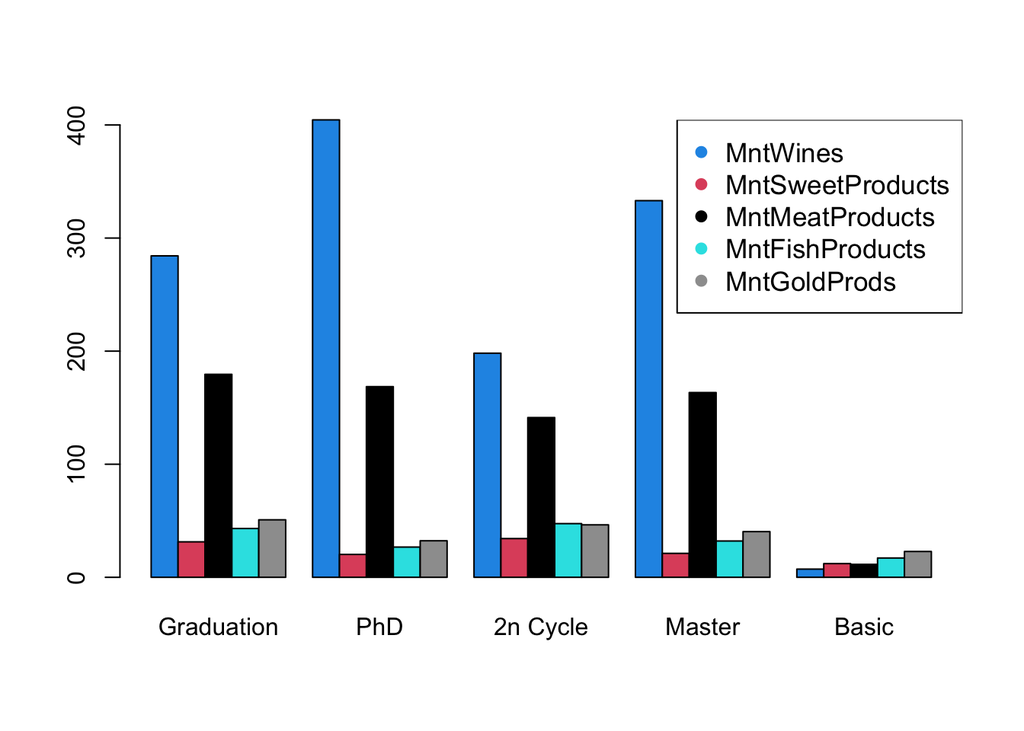

```r
barplot(tbl, beside = T, col = colspec)
legend("topright", inset = c(0,0), legend = varlist, col = colspec, pch = 16, cex = 1.1)
```

Defining ‘agegrp’:

```r
agegrp = ifelse(market$Year_Birth < 1960, "<1960",
              ifelse(market$Year_Birth < 1970, "[1960,1970)",
                  ifelse(market$Year_Birth < 1980, "[1970,1980)", ">=1980")))
```

The variable ‘agegrp’ classifies the data into four age groups according to the year of birth (<1960; 1960~1970; 1970~1980; >=1980).  
Applying `table()`:

```r
age_tbl = table(agegrp)
age_tbl
```

```
## agegrp
## [1960,1970) [1970,1980)       <1960      >=1980
##         506         740         570         424
```

Redefining `myf()` for ‘agegrp’:

```r
myf = function(var,agegrp)
{
  by = unique(agegrp)
  mout = NULL
  for(i in by){
    s = subset(var, agegrp == i)
    m = colMeans(s)
    mout = cbind(mout, m)
  }
  colnames(mout) = by
  mout
}
```

Applying `myf()`:

```r
varlist = c("Kidhome","Teenhome")
colspec = c(6, 7)
tbl = myf(subset(market, , varlist), market$Education)
tbl
```

```
##          Graduation       PhD  2n Cycle    Master      Basic
## Kidhome   0.4445430 0.4012346 0.4778325 0.4540541 0.62962963
## Teenhome  0.4942325 0.5987654 0.4088670 0.5351351 0.09259259
```

The function `subset()` returns data frames that meet conditions. `subset(market, , varlist)` returns the subset of the columns ‘Kidhome’ and ‘Teenhome’.  
Since `myf()` cross compares the two specified variables, ‘tbl’ gives the result of the cross comparison between ‘varlist’ (‘Kidhome’ & ‘Teenhome’) and ‘Education’.  
Generating the barplot:

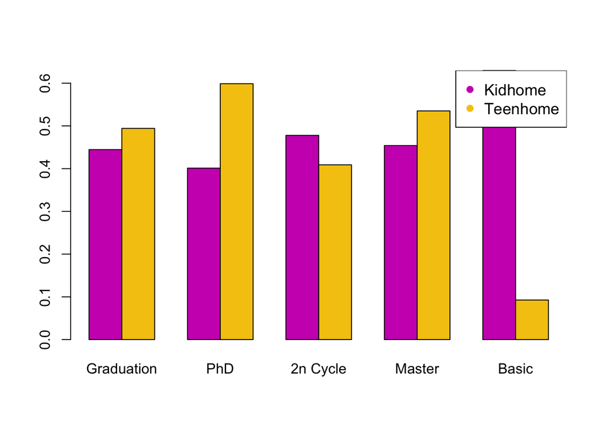

```r
barplot(tbl, beside = T, col = colspec)
legend("topright", inset = c(0,0), legend = varlist, col = colspec, pch = 16, cex = 1.1)
```